# MSiA 401 HW1

Group #9: Qiana Yang, Qiaozhen Wu, Yijun Wu, Dian Yu

9/27/2020

#### 2.1

Set $\frac{\partial Q}{\partial \beta}=0$ to minimize Q and then get the expression for $\beta$:
$$\begin{equation}
\begin{split}
Q
&= \sum^n_{i=1}(y_i-\hat\beta x_i)^2 \\
\frac{\partial Q}{\partial \beta}
&= \sum^n_{i=1}2(-x_i)(y_i-\hat\beta x_i) =0\\
0
&= -2\sum^n_{i=1}(x_iy_i-\hat\beta {x_i}^2) \\
\hat\beta \sum^n_{i=1} {x_i}^2
&= \sum^n_{i=1}x_iy_i \\
\hat\beta
&= \frac{\sum^n_{i=1}x_iy_i}{\sum^n_{i=1} {x_i}^2 }
\end{split}
\end{equation}$$

#### 2.3

Set $\frac{\partial Q}{\partial \beta}=0$ to minimize Q and then get the expression for $\beta$:
$$\begin{equation}
\begin{split}
Q
&= \sum^n_{i=1}w_i(y_i-\hat\beta x_i)^2 \\
Q
&= \sum^n_{i=1}w_i(y_i^2-2\hat\beta x_i y_i+{\hat\beta}^2{x_i}^2)\\
\frac{\partial Q}{\partial \beta}
&= \sum^n_{i=1}w_i(-2x_i y_i+2\hat\beta{x_i}^2) =0\\
\hat\beta \sum^n_{i=1} w_i {x_i}^2
&= \sum^n_{i=1}w_i x_i y_i \\
\hat\beta
&= \frac{\sum^n_{i=1}w_i x_iy_i}{\sum^n_{i=1} w_i {x_i}^2 }
\end{split}
\end{equation}$$

#### 2.8: For the tall and short fathers considered in the example, calculate their sons’ heights assuming r = 0.25 and r = 0.75.

```r
father_s <- 64
father_t <- 72
sx <- 2.7
sy <- 2.7
father_bar <- 68
son_bar <- 69
r1 <- 0.25
r2 <- 0.75
```

```r
# when r = 0.25
son_s_1 <- r1*(sx/sy)*(father_s-father_bar)+son_bar
son_t_1 <- r1*(sx/sy)*(father_t-father_bar)+son_bar
#when r = 0.75
son_s_2 <- r2*(sx/sy)*(father_s-father_bar)+son_bar
son_t_2 <- r2*(sx/sy)*(father_t-father_bar)+son_bar
```

```r
#result
table <- data.frame("Father shorter"= c(son_s_1, son_s_2), "Father taller" = c(son_t_1, son_t_2))
row.names(table) <- c("r=.25", "r=.75")
table
```

```
##       Father.shorter Father.taller
## r=.25             68            70
## r=.75             66            72
```

```r
# when r is closer to 0, the predicted heights of sons are farther away from the y = x + 1 model. Conversely, when r is closer to 1, the predicted heights of sons are closer to the y = x + 1 model.
```

#### 2.9(1) Create scatter plots for S&P500 vs. IBM and S&P500 vs. Apple.

```r
# read file
stocks <- read.csv(here::here('IBM-Apple-SP500 RR Data.csv'), skip = 1)[, 1:4]

colnames(stocks) <- c("Date", "SP", "IBM", "Apple")

# examine file
summary(stocks)
```

```
##      Date                SP                IBM               Apple
##  Length:104         Length:104         Length:104         Length:104
##  Class :character   Class :character   Class :character   Class :character
##  Mode  :character   Mode  :character   Mode  :character   Mode  :character
```

```r
head(stocks)
```

```
##       Date     SP    IBM   Apple
## 1 9/3/2013  3.95%  4.22%   0.39%
## 2 8/1/2013 -3.13% -6.08%   8.38%
## 3 7/1/2013  4.95%  2.06%  14.12%
## 4 6/3/2013 -1.50% -8.13% -11.83%
## 5 5/1/2013  2.08%  3.19%   2.24%
## 6 4/1/2013  1.81% -5.05%   0.03%
```

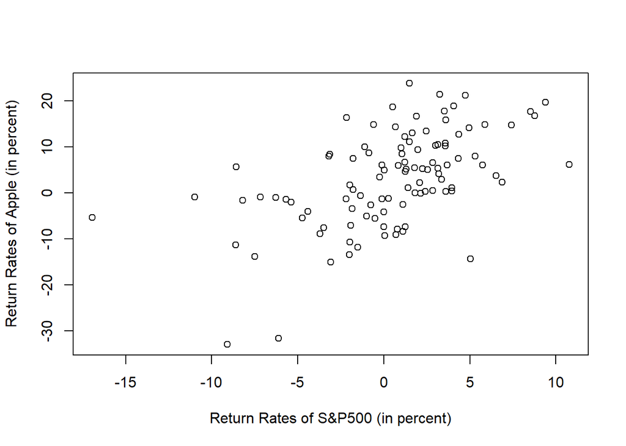

```r
# find and replace '%'. Set each column 2-4 as numeric.
stocks[, 2:4] <- lapply(stocks[, 2:4], function(x) as.numeric(gsub("%", "", x)))

# create scatter plots
plot_Apple <- plot(stocks$SP, stocks$Apple, xlab = "Return Rates of S&P500 (in percent)", ylab = "Return Rates of Apple (in percent)")
```

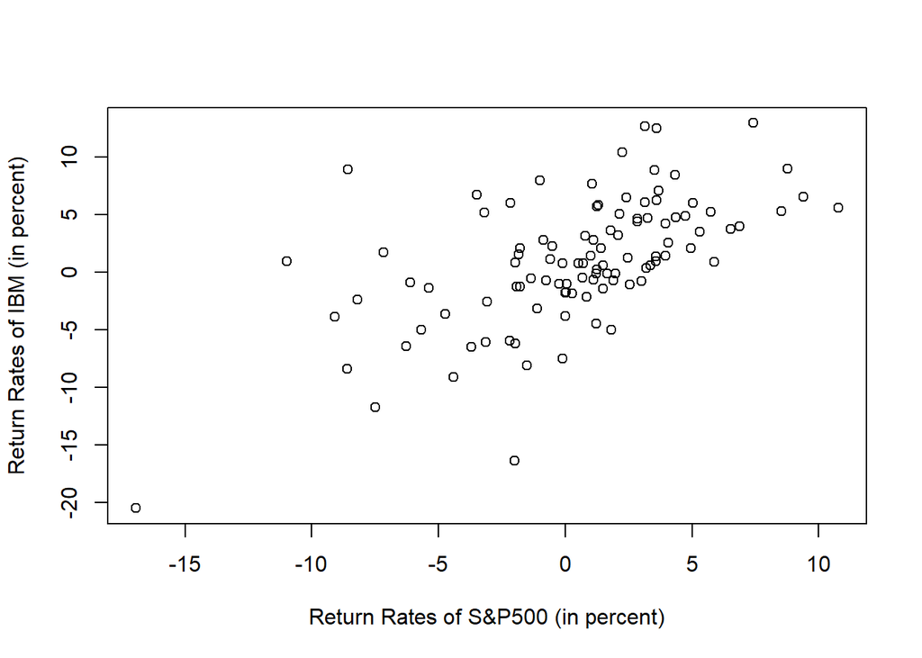

```r
plot_IBM <- plot(stocks$SP, stocks$IBM, xlab = "Return Rates of S&P500 (in percent)", ylab = "Return Rates of IBM (in percent)")
```

```r
## Both scatter plots present positive correlation between the return rates of S&P500 and those of Apple and IBM. Overall, Apple was more sensitive to the S&P rates than IBM - the slope of the LS line for Apple VS. S&P has a greater magnitude.
```